# Análise de Gastos de Deputados: Nossas Perguntas

Daniyel Rocha

3 de Setembro de 2018

# Sobre os dados

As informações utilizadas são referentes aos gastos com a CEAP (cota para o exercício da atividade parlamentar). Esses valores representam uma cota única mensal, destinada a custear os gastos dos deputados federais exclusivamente vinculados ao exercício da atividade parlamentar. Os dados foram coletados do site de transparência da Câmara, tratados, e podem ser baixados neste [link](https://canvas.instructure.com/courses/1402758/files/67618888/download?verifier=ibyou5PYo9aaFgRaefc0keYkHhkQ2EqIArdmI1bq&wrap=1).

Outros dados que fazem parte da análise são os valores com os limites de CEAP para cada estado. O valor máximo mensal da cota depende da unidade da federação que o deputado representa. Essa variação ocorre por causa das passagens aéreas e está relacionada ao valor do trecho entre Brasília e o Estado que o deputado representa. Os dados podem ser baixados [aqui](https://canvas.instructure.com/courses/1402758/files/67618889/download?verifier=vfi4jwcg26IVtelxRY7Sm5RnhrAuKcNrOrw2Yt6Y).

A seguir, fazemos a leitura desses dados e observamos uma pequena amostra.

```r
glimpse(dados)
```

```
Observations: 963,452
Variables: 13
$ nomeParlamentar <chr> "ABEL MESQUITA JR.", "ABEL MESQUITA JR.", "ABEL MESQUITA JR.", "ABEL MESQUITA JR.", "ABEL MESQUI...
$ idCadastro      <int> 178957, 178957, 178957, 178957, 178957, 178957, 178957, 178957, 178957, 178957, 178957, 178957, ...
$ sgUF            <chr> "RR", "RR", "RR", "RR", "RR", "RR", "RR", "RR", "RR", "RR", "RR", "RR", "RR", "RR", "RR", "RR", ...
$ sgPartido       <chr> "DEM", "DEM", "DEM", "DEM", "DEM", "DEM", "DEM", "DEM", "DEM", "DEM", "DEM", "DEM", "DEM", "DEM"...
$ tipoDespesa     <chr> "MANUTENÇÃO DE ESCRITÓRIO DE APOIO À ATIVIDADE PARLAMENTAR", "MANUTENÇÃO DE ESCRITÓRIO DE APOIO ...
$ especDespesa    <chr> NA, NA, NA, NA, NA, "Veículos Automotores", "Veículos Automotores", "Veículos Automotores", "Veí...
$ fornecedor      <chr> "COMPANHIA DE AGUAS E ESGOTOS DE RORAIMA", "COMPANHIA DE AGUAS E ESGOTOS DE RORAIMA", "ELETROBRA...
$ CNPJCPF         <chr> "05939467000115", "05939467000115", "02341470000144", "02341470000144", "00540252000103", "08202...
$ tipoDocumento   <int> 0, 0, 0, 0, 0, 0, 0, 0, 0, 0, 0, 0, 0, 0, 0, 0, 0, 0, 0, 0, 0, 0, 0, 0, 0, 0, 0, 0, 0, 0, 0, 0, ...
$ dataEmissao     <dttm> 2015-11-14 00:00:00, 2015-12-10 00:00:00, 2015-11-27 00:00:00, 2015-12-30 00:00:00, 2015-02-23 ...
$ valorDocumento  <dbl> 165.65, 59.48, 130.95, 196.53, 310.25, 32.00, 50.00, 50.00, 75.00, 170.02, 100.00, 80.00, 193.00...
$ valorGlosa      <dbl> 0, 0, 0, 347, 0, 0, 0, 0, 0, 0, 0, 0, 0, 0, 0, 0, 0, 0, 0, 0, 0, 0, 0, 0, 0, 0, 0, 0, 0, 0, 0, 0...
$ valorLíquido    <dbl> 165.65, 59.48, 130.95, 193.06, 310.25, 32.00, 50.00, 50.00, 75.00, 170.02, 100.00, 80.00, 193.00...
```

# 1. Quais são os deputados que gastaram mais dinheiro da CEAP? Quais são os mais econômicos?

Para responder as perguntas, podemos agrupar os dados de modo a somar as despesas totais de cada parlamentar. Dessa forma podemos saber quais são aqueles que mais gastaram e os que foram mais econômicos. Como a base de dados fornece um grande número de deputados, podemos escolher uma amostra pequena para responder cada uma das perguntas.

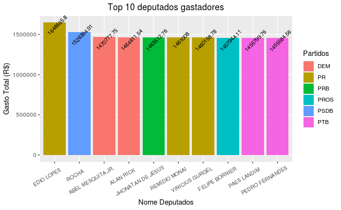

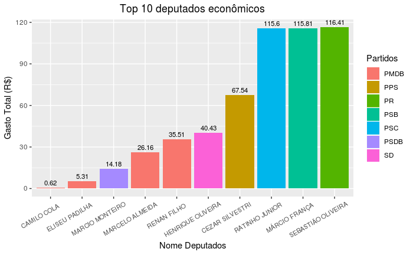

# 2. Quais os estados cujos deputados gastam mais no exterior? Quais os estados cujos deputados gastam menos no exterior?

Para responder, é preciso selecionar o tipo de documento adequado aos gastos feitos no exterior. Após isso, podemos sumarizar o gasto total realizado pelos parlamentares de cada estado.

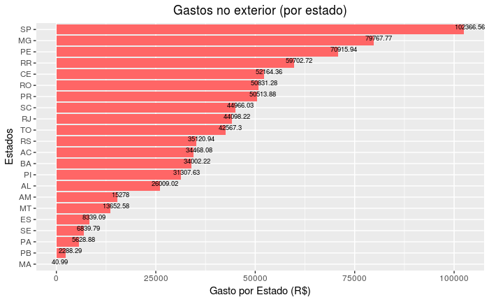

Observando os gráficos, temos que os estados que mais gastam no exterior são São Paulo, Minas Gerais e Pernambuco, enquanto os que menos gastaram no exterior são os estados do Maranhão, Paraíba e Pará.

# 3. Quais os partidos cujos parlamentares mais usam CEAP no estado da Paraíba? Quais são os que menos usam? Mesmas perguntas considerando valores em R$.

Para responder a primeira parte dessa pergunta precisamos inicialmente filtrar os parlamentares do estado da Paraíba. Em seguida, realizamos uma contagem para saber a quantidade de gastos com o CEAP de cada parlamentar e então selecionar os que mais utilizaram, para cada partido. Dessa forma, conseguimos saber quais são os partidos que têm deputados que mais usam o CEAP. Com as informações de parlamentares da PB também podemos responder a outra parte da questão. Agora queremos saber os partidos dos parlamentares que mais geraram gastos. Para isso, descobrimos o valor total gasto por um deputado e então selecionamos os maiores gastos para cada partido.

```r
dados_pb <- dados %>%
  filter(sgUF == "PB")
mais_despesa_parlamentares_pb <- dados_pb %>%
  filter(valorLíquido > 0) %>%
  group_by(nomeParlamentar, sgPartido) %>%
  summarise(num_usos = n())
#partidos dos que mais e menos usam o CEAP
uso_ceap_partido <- mais_despesa_parlamentares_pb %>%
  group_by(sgPartido) %>%
  summarise(maiores_num_usos = max(num_usos)) %>%
  arrange(desc(maiores_num_usos))

#partidos dos parlamentares que mais gastaram
partidos_gastadores_pb <- dados_pb %>%
  group_by(nomeParlamentar, sgPartido) %>%
  summarise(gastos_PB = sum(valorLíquido)) %>%
  group_by(sgPartido) %>%
  summarise(maiores_gastos = max(gastos_PB)) %>%
  arrange(desc(maiores_gastos))
```

Graficamente temos:

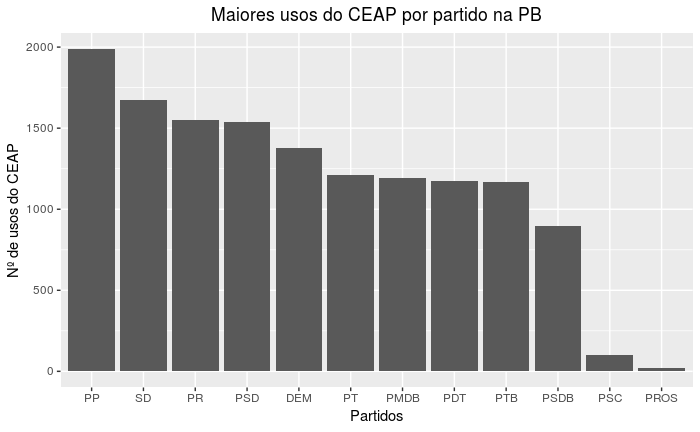

```r
uso_ceap_partido %>%
  ggplot(aes(x=reorder(sgPartido, -maiores_num_usos), y=maiores_num_usos)) +
  geom_bar(stat = "identity") +
  xlab("Partidos") + ylab("Nº de usos do CEAP") +
  ggtitle("Maiores usos do CEAP por partido na PB") +
  theme(plot.title = element_text(hjust = 0.5))
```

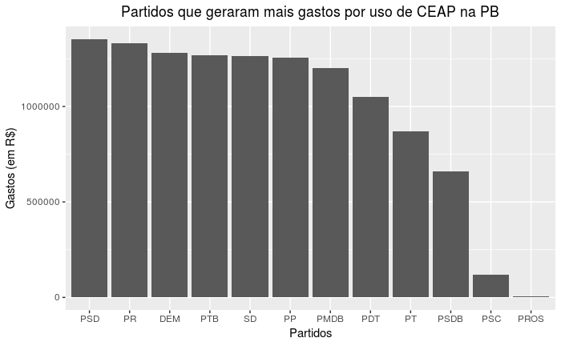

```r
partidos_gastadores_pb %>%
  ggplot(aes(x=reorder(sgPartido, -maiores_gastos), y=maiores_gastos)) +
  geom_bar(stat = "identity") +
  xlab("Partidos") + ylab("Gastos (em R$)") +
  ggtitle("Partidos que geraram mais gastos por uso de CEAP na PB") +
  theme(plot.title = element_text(hjust = 0.5))
```

Com os gráficos gerados, podemos ver que o PP, SD e PR foram os partidos da Paraíba que mais fizeram uso do CEAP, enquanto PSDB, PSC e PROS utilizaram tem os menores usos de CEAP. Com relação aos gastos gerados, PSD, PR e DEM foram os que deram origem aos maiores gastos no uso de CEAP no estado. Já PSDB, PSC e PROS novamente são partidos que gastaram pouco com relação aos restantes, mostrando alguma relação entre utilizar pouco e gerar pouco gasto.

# 4. Quais os deputados que mais ultrapassam o limite de CEAP do seu estado?

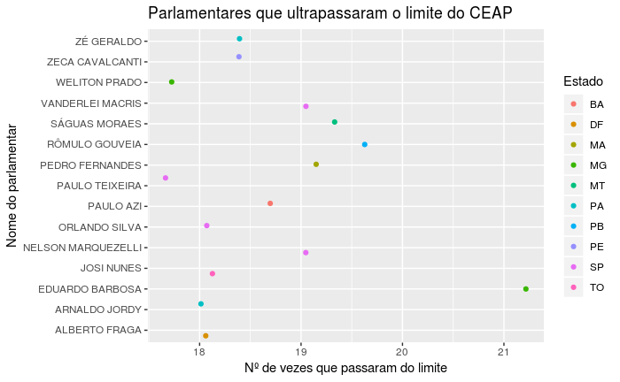

```r
parlamentares_sem_limites %>%
  top_n(10) %>%
  ggplot(aes(x=nomeParlamentar, y=n_acima_limite, col = sgUF)) +
  geom_jitter() +
  coord_flip() +
  ylab("Nº de vezes que passaram do limite") + xlab("Nome do parlamentar") +
  labs(col = "Estado") +
  ggtitle("Parlamentares que ultrapassaram o limite do CEAP")
```

O método utilizado para a resposta foi o de agrupar o gasto gerado mensalmente por cada parlamentar. Com isso, podemos filtrar para considerar somente os gastos que ultrapassavam o limite mensal estadual. Para saber os parlamentares que mais ultrapassaram o limite foi necessário apenas realizar uma contagem para observar o resultado esperado, que pode ser visto no gráfico acima.

# 5. Quais estados cujos parlamentares gastam mais com passagens aéreas?

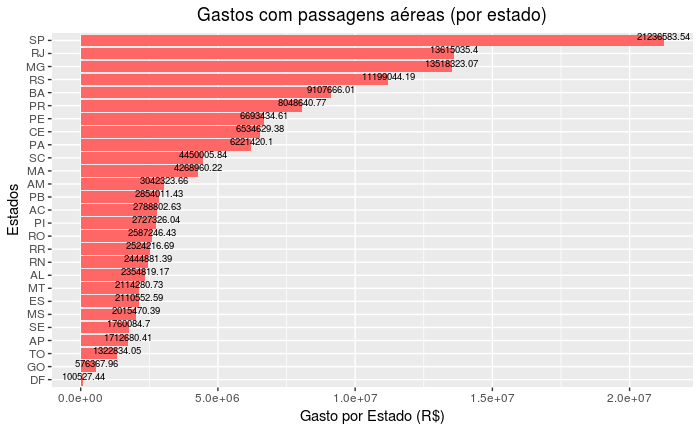

Observando o gráfico acima, podemos ver que os parlamentares dos estados de Sâo Paulo, Rio de Janeiro e Minas Gerais apresentam um gasto com passagens aéreas muito maior do que o restante dos deputados do país.

# 6. Escolha três partidos e responda: Quais são os tipos de despesa mais utilizados no uso da CEAP pelos deputados desses partidos? Mesma pergunta considerando valores em R$.

Podemos selecionar aleatoriamente três partidos para responder a pergunta. Com isso feito, o passo seguinte é agrupar os dados por despesas mais utilizadas e por maiores gastos, realizando a filtragem para considerar os deputados dos partidos escolhidos.

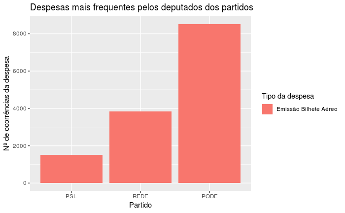

```r
set.seed(1)
#selecionando aleatoriamente tres partidos
partidos <- dados %>%
  select(sgPartido) %>%
  distinct() %>%
  na.omit() %>%
  sample_n(3)
#agrupando as despesas por partido e filtrando as maiores despesas
top_despesas_partido <- dados %>%
  group_by(sgPartido, tipoDespesa) %>%
  summarise(num_ocorrencias = n()) %>%
  filter(num_ocorrencias == max(num_ocorrencias)) %>%
  na.omit()
#selecionando as despesas dos partidos escolhidos que geram mais gastos
top_gastos_partido <- dados %>%
  filter(valorLíquido > 0) %>%
  group_by(sgPartido, tipoDespesa) %>%
  summarise(soma_despesa = sum(valorLíquido)) %>%
  filter(soma_despesa == max(soma_despesa)) %>%
  na.omit()
top_despesas_partido %>%
  filter(sgPartido %in% partidos$sgPartido) %>%
  ggplot(aes(x = reorder(sgPartido, num_ocorrencias), y=num_ocorrencias, fill=tipoDespesa)) +
  geom_bar(stat = "identity") +
  xlab("Partido") + ylab("Nº de ocorrências da despesa") + labs(fill = "Tipo da despesa") +
  ggtitle("Despesas mais frequentes pelos deputados dos partidos")
```

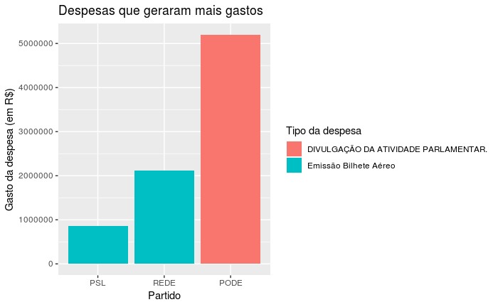

```r
top_gastos_partido %>%
  filter(sgPartido %in% partidos$sgPartido) %>%
  ggplot(aes(x = reorder(sgPartido, soma_despesa), y=soma_despesa, fill=tipoDespesa)) +
  geom_bar(stat = "identity") +
  xlab("Partido") + ylab("Gasto da despesa (em R$)") + labs(fill = "Tipo da despesa") +
  ggtitle("Despesas que geraram mais gastos")
```

Os partidos escolhidos aleatoriamente foram PSL, REDE e PODE. Podemos ver que em ambos os casos a despesa dominante foi a Emissão de Bilhetes Aéreos, sendo que a divulgação de atividade parlamentar foi uma despesa que gerou muito gasto para o partido PODE.